# Homework_06

Arora

October 19, 2017

### Part One: One and Two Sized Z Test for Proportion Data

```r
Z.prop.test <- function(p1, n1, p0, p2, n2, alternative = "two.tailed", conf.level = 0.975, k=10)
    p<-rep(NA, k)
    for (i in 1:k){
      p1
      n1<-n
      p0
      conf.level<-0.975
      p2<-NULL
      n2<-NULL
      alpha=0.05
      Z <- p2-p1/(sqrt((p0)*(1-p0)*((1/n1)+(1/n2))))
      alternative<-"two tailed"

    if (alternative == "less") {
            P<-p[i] <- pnorm(z, lower.tail = TRUE)  # calculates the associated p value
            hyp <- "p1 < p0"
        }
        if (alternative == "greater") {
            P<-p[i] <- pnorm(z, lower.tail = FALSE)
            hyp <- "p1 > p0"
        }
        if (alternative == "two.tailed") {
            if (z > 0) {
                P<-p[i] <- 2 * pnorm(z, lower.tail = FALSE)
            }
            if (z < 0) {
                P<-p[i] <- 2 * pnorm(z, lower.tail = TRUE)
            }

    if (p2 == is.NULL) {
      Z=(p1-p0)/sqrt((p0*(1-p0))/n1)
    }
     if (alternative == "less") {
            P<-p[i] <- pnorm(z, lower.tail = TRUE)  # calculates the associated p value
            hyp <- "p1 < p0"
        }
        if (alternative == "greater") {
            P<-p[i] <- pnorm(z, lower.tail = FALSE)
            hyp <- "p1 > p0"
        }
        if (alternative == "two.tailed") {
            if (z > 0) {
                P<-p[i] <- 2 * pnorm(z, lower.tail = FALSE)
            }
            if (z < 0) {
                P<-p[i] <- 2 * pnorm(z, lower.tail = TRUE)
            }

    if (n2 == is.NULL) {
     Z=(p1-p0)/sqrt((p0*(1-p0))/n1)
    }
     if (alternative == "less") {
            P<-p[i] <- pnorm(z, lower.tail = TRUE)  # calculates the associated p value
            hyp <- "p1 < p0"
        }
        if (alternative == "greater") {
            P<-p[i] <- pnorm(z, lower.tail = FALSE)
            hyp <- "p1 > p0"
        }
        if (alternative == "two.tailed") {
            if (z > 0) {
                P<-p[i] <- 2 * pnorm(z, lower.tail = FALSE)
            }
            if (z < 0) {
                P<-p[i] <- 2 * pnorm(z, lower.tail = TRUE)
            }
      }
    }
  }

      alpha=0.05
      critical.value<-qnorm(1-alpha/2)
      p1.CI<-((p1*(1-p1))/n1)
      p2.CI<-((p2*(1-p2))/n2)
      SE=sqrt(p1.CI+p2.CI)
      addition<-(p1+p2)+(critical.value*SE)
      addition
      subtraction<-(p1+p2)-(critical.value*SE)
      subtraction
      CI<-c(subtraction, addition)


      #p is the probability of the sucess where s=1 and failure = 0
    p<-p1 #isn't that what the probability proportion is?
    n1 #this is the number of trials run
    if(n1*p1<5) {
        "Warning: the input does not allow for normality to be assumed"
    }
    if(n1*(1*p1)<5) {"Warning: the input does not allow for normality to be assumed"
    ##I didn't know which n and p where referred in this particular part of the homework so I used n1 and p1 because that seemed most logical
    }

return(Z)
    return(P)
    return(CI)
}
```

```r
library(curl)
library(ggplot2)
f <- curl("https://raw.githubusercontent.com/fuzzyatelin/fuzzyatelin.github.io/master/AN597_Fall17/KamilarAndCooperData.csv")
d <- read.csv(f, header = TRUE, sep = ",", stringsAsFactors = FALSE)
head(d)
```

```
##               Scientific_Name          Family          Genus      Species
## 1 Allenopithecus_nigroviridis Cercopithecidae Allenopithecus nigroviridis
## 2         Allocebus_trichotis Cercopithecidae      Allocebus    trichotis
## 3           Alouatta_belzebul        Atelidae       Alouatta     belzebul
## 4             Alouatta_caraya        Atelidae       Alouatta       caraya
## 5            Alouatta_guariba        Atelidae       Alouatta      guariba
## 6           Alouatta_palliata        Atelidae       Alouatta     palliata
##   Brain_Size_Species_Mean Brain_Size_Female_Mean   Brain_size_Ref
## 1                   58.02                  53.70 Isler et al 2008
## 2                      NA                     NA
## 3                   52.84                  51.19 Isler et al 2008
## 4                   52.63                  47.80 Isler et al 2008
## 5                   51.70                  49.08 Isler et al 2008
## 6                   49.88                  48.04 Isler et al 2008
##   Body_mass_male_mean Body_mass_female_mean Mass_Dimorphism
```

[output cut: 69 more lines]

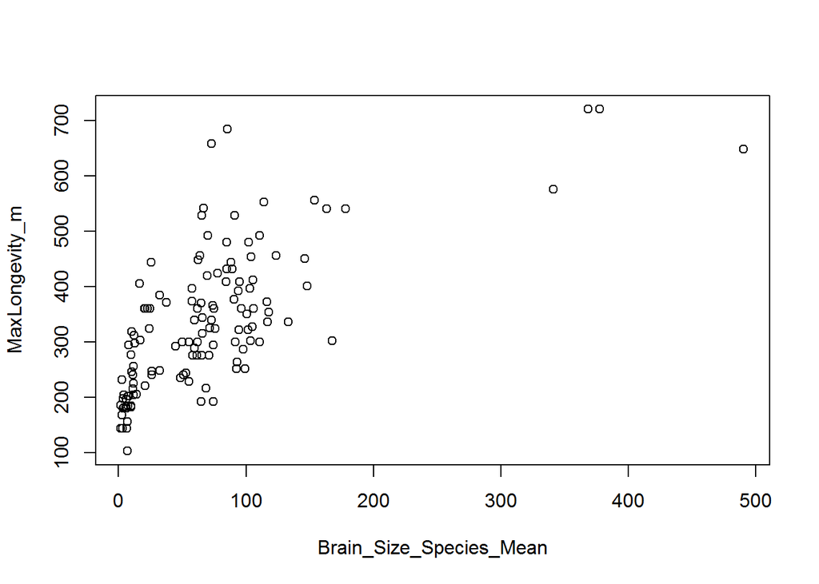

```r
plot(data=d, MaxLongevity_m ~ Brain_Size_Species_Mean)
```

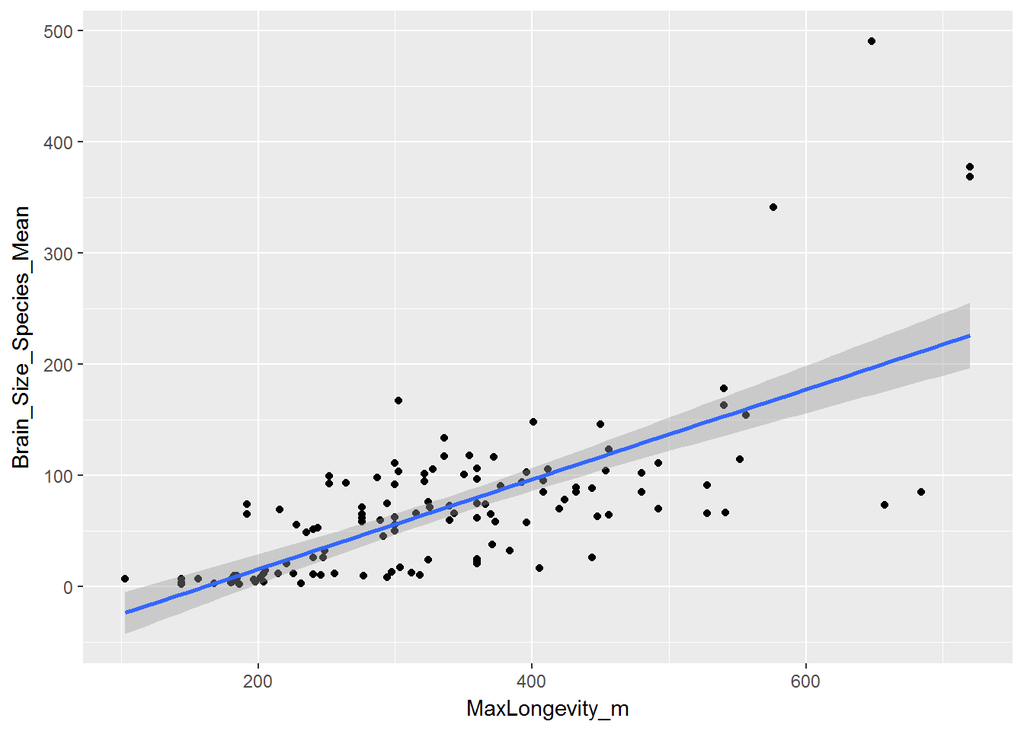

```r
g<-ggplot(data=d, aes(x=MaxLongevity_m, y=Brain_Size_Species_Mean))
g<-g+geom_point()
g<-g+geom_smooth(method="lm", formula=y~x)
g
```

####there were 85 points removed that were non-finite

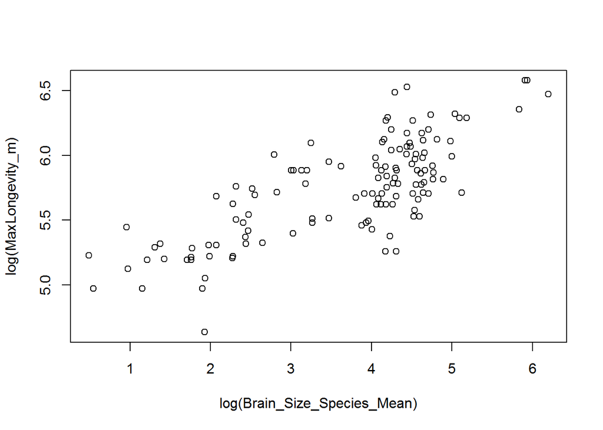

```r
plot(data=d, log(MaxLongevity_m) ~ log(Brain_Size_Species_Mean))
```

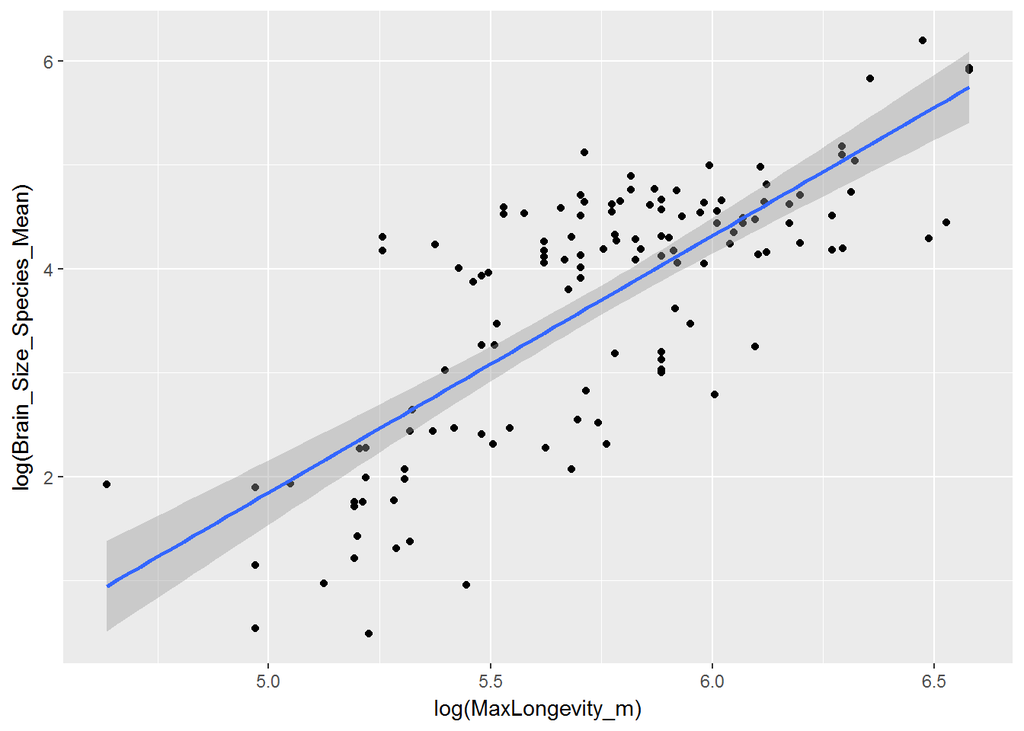

```r
g<-ggplot(data=d, aes(x=log(MaxLongevity_m), y=log(Brain_Size_Species_Mean)))
g<-g+geom_point()
g<-g+geom_smooth(method="lm", formula=y~x)
g
```

####again, another 85 points were formed for being non-finite

##### Using your model, add lines for the 90 percent confidence and prediction interval bands on the plot and add a legend to differentiate between the lines.

##### Produce a point estimate and associated 90 percent PI for the longevity of a species whose brain weight is 800 gm. Do you trust the model to predict observations accurately for this value of the explanatory variable? Why or why not?

##### Looking at your two models, which do you think is better? Why?